# An Open-Source Dynamic Microsimulation Framework for Obesity and Health-Economic Modelling

MMOS-PT

Author

Berta Valente

Published

August 20, 2026

## 1 Input Preparation

Model inputs were pre-processed before simulation and include the 1998 baseline population, repeated NHS BMI data, mortality life tables, entrant donor pools, and model settings. The analysis loads the prepared input object and validates the required components before simulation.

```r
prepared_inputs_file <- file.path(
  project_root,
  "data-raw",
  "model_inputs_prepared.rds"
)

prepare_script_file <- file.path(
  project_root,
  "data-raw",
  "prepare_model_inputs.R"
)

if (!file.exists(prepared_inputs_file)) {
  if (!file.exists(prepare_script_file)) {
    stop(
      "Neither prepared inputs nor preparation script were found:\n",
      prepared_inputs_file, "\n",
      prepare_script_file,
      call. = FALSE
    )
  }

  old_wd <- getwd()
  on.exit(setwd(old_wd), add = TRUE)
  setwd(project_root)

  source(prepare_script_file, local = new.env(parent = globalenv()))

  if (!file.exists(prepared_inputs_file)) {
    stop(
      "`prepare_model_inputs.R` completed but did not create:\n",
      prepared_inputs_file,
      call. = FALSE
    )
  }
}

inputs <- readRDS(prepared_inputs_file)

required_input_names <- c(
  "population_1998",
  "bmi_panel",
  "life_table",
  "donor_pool_1998",
  "donor_pool_2005",
  "donor_pool_2014",
  "donor_pool_2019",
  "settings"
)

missing_inputs <- setdiff(required_input_names, names(inputs))

if (length(missing_inputs) > 0L) {
  stop(
    "Model inputs missing: ",
    paste(missing_inputs, collapse = ", "),
    call. = FALSE
  )
}

population_1998 <- inputs$population_1998
bmi_panel <- inputs$bmi_panel
life_table <- inputs$life_table
donor_pool_1998 <- inputs$donor_pool_1998
donor_pool_2005 <- inputs$donor_pool_2005
donor_pool_2014 <- inputs$donor_pool_2014
donor_pool_2019 <- inputs$donor_pool_2019
settings_base <- inputs$settings
```

## 2 Derived Inputs

Three objects must be constructed before the simulation can run:

- **`rr_bmi`** — all-cause mortality relative risks by BMI category and sex, with normal weight as reference.
- **`rr_education`** — all-cause mortality relative risks by education level.
- **`bmi_transition_model`** — synthetic-cohort BMI-transition model fitted from the repeated NHS cross-sections.

```r
rr_bmi <- tibble::tribble(
  ~sex,      ~bmi_category,    ~rr_bmi,
  "men",     "underweight",    1.85,
  "men",     "normal_weight",  1.00,
  "men",     "overweight",     0.94,
  "men",     "obesity_I",      1.12,
  "men",     "obesity_II",     1.42,
  "men",     "obesity_III",    1.92,
  "women",   "underweight",    1.82,
  "women",   "normal_weight",  1.00,
  "women",   "overweight",     0.97,
  "women",   "obesity_I",      1.09,
  "women",   "obesity_II",     1.38,
  "women",   "obesity_III",    1.85
)
```

```r
# Mackenbach et al. (2024), Lancet Public Health.
# Lower education carries higher all-cause mortality risk.
rr_education <- tibble::tibble(
  education_level2 = c("lower", "higher"),
  rr_education = c(1.20, 0.90)
)
```

```r
bmi_panel_prepared <- ponte_prepare_bmi_panel(bmi_panel)

bmi_transitions <- ponte_build_bmi_synthetic_cohorts(
  bmi_panel_prepared
)

bmi_transition_model <- ponte_fit_bmi_transition(
  bmi_transitions,
  projection_period = 2014L
)
```

## 3 Module 1: Obesity Trajectories 1998–2040

The simulation initialises in 1998 from the full NHS baseline population, aged 20–84 years. From 1999 onwards, new age-20 entrants are sampled from period-specific donor pools. Retrospective comparisons at the 2005, 2014, and 2019 NHS cross-sections are calibration diagnostics: they are not independent external validation because those data contribute to transition estimation and entrant-pool construction.

### 3.1 Simulation Settings

```r
settings_historical <- ponte_settings(
  initial_year = 1998L,
  projection_end_year = 2040L,
  entry_age = 20L,
  max_age = 84L,
  n_simulations = n_simulations_main,
  entrant_n_per_year = 100L,
  seed = 20260817L
)
```

### 3.2 Entrant Targets

New entrants are assigned the weighted NHS population size at age 20 for the survey wave closest to their entry year. The donor-wave allocation is 1998 for entry years 1999–2004, 2005 for 2005–2013, 2014 for 2014–2018, and 2019 for 2019–2040.

```r
entrant_by_wave <- bmi_panel |>
  filter(age == 20L, year %in% c(1998L, 2005L, 2014L, 2019L)) |>
  group_by(year, sex) |>
  summarise(
    entrant_population = sum(survey_weight, na.rm = TRUE),
    .groups = "drop"
  ) |>
  rename(wave_year = year)

entry_years <- seq.int(
  settings_historical$initial_year + 1L,
  settings_historical$projection_end_year
)

entrant_targets_historical <- tidyr::expand_grid(
  entry_year = entry_years,
  sex = c("men", "women")
) |>
  mutate(
    wave_year = case_when(
      entry_year <= 2004L ~ 1998L,
      entry_year <= 2013L ~ 2005L,
      entry_year <= 2018L ~ 2014L,
      TRUE ~ 2019L
    )
  ) |>
  left_join(entrant_by_wave, by = c("wave_year", "sex")) |>
  select(entry_year, sex, entrant_population) |>
  mutate(
    entry_year = as.integer(entry_year),
    entrant_population = as.numeric(entrant_population)
  ) |>
  arrange(entry_year, sex)

if (anyNA(entrant_targets_historical$entrant_population)) {
  stop(
    "Entrant targets are missing. Check bmi_panel includes age == 20 in all NHS waves.",
    call. = FALSE
  )
}

ponte_validate_entrant_targets(
  entrant_targets = entrant_targets_historical,
  start_year = settings_historical$initial_year + 1L,
  end_year = settings_historical$projection_end_year
)

write_result_csv(entrant_targets_historical, "module1_entrant_targets.csv")
```

### 3.3 Simulation

The result is stored as a versioned RDS file in `analysis/results/`. Increment `simulation_version` whenever model inputs, simulation logic, or model parameters that affect results are changed.

```r
donor_pools_module1 <- list(
  list(from = 1999L, to = 2004L, pool = donor_pool_1998),
  list(from = 2005L, to = 2013L, pool = donor_pool_2005),
  list(from = 2014L, to = 2018L, pool = donor_pool_2014),
  list(from = 2019L, to = 2040L, pool = donor_pool_2019)
)

sim_path <- file.path(results_dir, sim_rds)

if (file.exists(sim_path)) {
  simulation_historical <- readRDS(sim_path)

  cached_simulations <- dplyr::n_distinct(simulation_historical$simulation)
  if (cached_simulations != n_simulations_main) {
    stop(
      "Cached simulation has ", cached_simulations,
      " simulation(s), but n_simulations_main is ", n_simulations_main,
      ". Delete the stale cache or increment simulation_version.",
      call. = FALSE
    )
  }
} else {
  simulation_historical <- ponte_run_simulation(
    population = population_1998,
    settings = settings_historical,
    life_table = life_table,
    rr_bmi = rr_bmi,
    rr_education = rr_education,
    donor_pool = donor_pool_1998,
    donor_pools = donor_pools_module1,
    entrant_targets = entrant_targets_historical,
    bmi_transition_model = bmi_transition_model,
    bmi_update_method = "legacy",
    stochastic_bmi = TRUE,
    education_source = "existing",
    bmi_limits = c(10, 80)
  )

  save_result_rds(simulation_historical, sim_rds)
  write_result_csv(
    simulation_historical,
    paste0("module1_simulation_1998_2040_", simulation_version, ".csv")
  )
}
```

### 3.4 BMI Trajectory Summary

Table 1: Simulated mean BMI and obesity prevalence by sex and education level at selected years.

| Year | Sex | Education | Mean BMI | Obesity prevalence | Records (sim) |
| --- | --- | --- | --- | --- | --- |
| 1998 | men | high | 24.60 | 4.6% | 1345 |
| 1998 | men | low | 26.17 | 13.4% | 10838 |
| 1998 | men | medium | 25.11 | 8.1% | 3411 |
| 1998 | women | high | 22.19 | 2.5% | 1774 |
| 1998 | women | low | 26.04 | 17.1% | 11514 |
| 1998 | women | medium | 23.28 | 5.6% | 3066 |
| 2005 | men | high | 24.84 | 5.5% | 1351 |
| 2005 | men | low | 26.50 | 14.5% | 9688 |
| 2005 | men | medium | 25.34 | 8.6% | 3430 |
| 2005 | women | high | 22.75 | 2.8% | 1847 |
| 2005 | women | low | 26.56 | 19.5% | 10688 |
| 2005 | women | medium | 23.79 | 5.8% | 3144 |
| 2014 | men | high | 25.29 | 6.1% | 1357 |
| 2014 | men | low | 26.93 | 16.6% | 7810 |
| 2014 | men | medium | 25.66 | 11.0% | 3451 |
| 2014 | women | high | 23.44 | 3.6% | 1916 |
| 2014 | women | low | 27.10 | 22.1% | 9020 |
| 2014 | women | medium | 24.53 | 8.7% | 3242 |
| 2019 | men | high | 25.59 | 6.3% | 1318 |
| 2019 | men | low | 27.19 | 18.6% | 6707 |
| 2019 | men | medium | 25.87 | 11.8% | 3429 |
| 2019 | women | high | 23.80 | 4.2% | 1930 |
| 2019 | women | low | 27.42 | 23.4% | 7873 |
| 2019 | women | medium | 24.77 | 9.5% | 3289 |
| 2030 | men | high | 26.06 | 9.1% | 1228 |
| 2030 | men | low | 27.71 | 21.7% | 4403 |
| 2030 | men | medium | 26.18 | 14.2% | 3279 |
| 2030 | women | high | 24.64 | 5.8% | 1954 |
| 2030 | women | low | 27.92 | 25.7% | 5266 |
| 2030 | women | medium | 25.76 | 13.7% | 3228 |
| 2040 | men | high | 26.41 | 11.6% | 1105 |
| 2040 | men | low | 28.04 | 25.1% | 2586 |
| 2040 | men | medium | 26.49 | 15.7% | 2973 |
| 2040 | women | high | 25.30 | 8.3% | 1772 |
| 2040 | women | low | 28.23 | 27.0% | 3001 |
| 2040 | women | medium | 26.34 | 16.5% | 3012 |

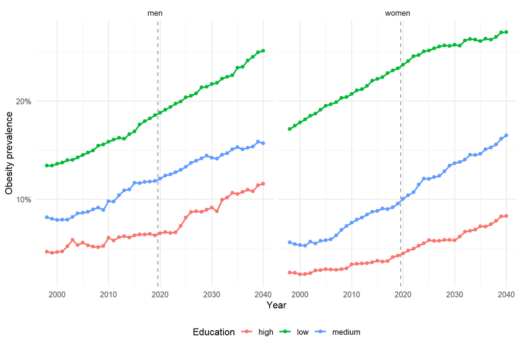

Figure 1: Simulated obesity prevalence by sex and education level, 1998–2040. The dashed vertical line marks 2019, the final observed NHS wave used for the internal calibration comparison.

### 3.4a Mortality Input Consistency Check

> **Classification:** Internal consistency check / dependent calibration. The Portuguese life table is an input to the simulation, so this is not independent mortality validation. The comparison assesses whether simulated age-sex mortality is broadly consistent with life-table mortality after BMI and education relative-risk adjustments.

Table 2: Mortality input consistency: life-table central death rate versus simulated death rate for the 1998 exposure period, by sex and age group. Deaths recorded in 1999 arise from the 1998 to 1999 transition. Differences reflect relative-risk adjustment and stochastic variation.

| Sex | Age band | Life-table mx / 1,000 | Simulated mx / 1,000 | Ratio (sim/LT) | Absolute difference |
| --- | --- | --- | --- | --- | --- |
| men | 20–29 | 0.54 | 1.10 | 2.033 | 0.56 |
| men | 30–39 | 0.89 | 2.44 | 2.739 | 1.55 |
| men | 40–49 | 2.29 | 3.03 | 1.326 | 0.74 |
| men | 50–59 | 6.60 | 5.12 | 0.775 | -1.48 |
| men | 60–69 | 14.63 | 12.66 | 0.865 | -1.98 |
| men | 70–79 | 32.99 | 39.92 | 1.210 | 6.93 |
| men | 80–84 | 76.70 | 117.26 | 1.529 | 40.55 |
| women | 20–29 | 0.20 | 0.00 | 0.000 | -0.20 |
| women | 30–39 | 0.48 | 1.20 | 2.489 | 0.72 |
| women | 40–49 | 1.14 | 0.76 | 0.669 | -0.38 |
| women | 50–59 | 2.67 | 4.34 | 1.626 | 1.67 |
| women | 60–69 | 5.76 | 2.87 | 0.499 | -2.89 |
| women | 70–79 | 18.26 | 23.89 | 1.308 | 5.63 |
| women | 80–84 | 51.60 | 68.25 | 1.323 | 16.65 |

### 3.5 Retrospective Calibration

The simulated obesity prevalence is compared with observed NHS prevalence at the 2005, 2014, and 2019 survey waves. Because these waves contribute to parameter estimation and/or entrant pools, this is a dependent temporal calibration diagnostic, not independent validation.

Table 3: Dependent temporal calibration: simulated and observed NHS obesity prevalence at survey years. Interval estimates are shown only when at least 30 simulation runs are available.

| Year | Sex | Simulated | Observed (NHS) |
| --- | --- | --- | --- |
| 2005 | men | 11.8% | 15.1% |
| 2005 | women | 13.6% | 17.4% |
| 2014 | men | 13.1% | 15.7% |
| 2014 | women | 14.6% | 18.2% |
| 2019 | men | 14.1% | 17.4% |
| 2019 | women | 14.8% | 18.5% |

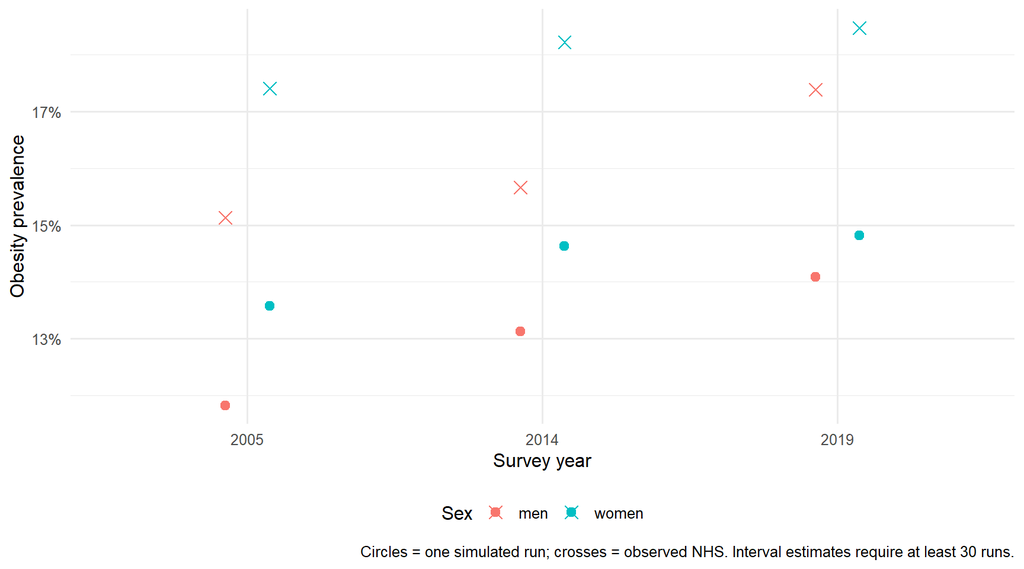

Figure 2: Dependent temporal calibration of obesity prevalence: simulated estimates versus observed NHS prevalence at 2005, 2014, and 2019. Circles denote simulated estimates and crosses denote observed NHS prevalence. Simulation intervals are displayed only for at least 30 runs.

### 3.6 Calibration Error Metrics

| Metric | Value |
| --- | --- |
| Mean absolute error | 3.37% |
| Root mean squared error | 3.39% |

Across the six sex-year comparisons, the model underestimates observed obesity prevalence consistently, with a mean absolute error of 3.37 percentage points. The directionally consistent negative bias indicates that the current BMI transition specification does not fully reproduce the observed population-level increase in obesity prevalence between 2005 and 2019. Because the NHS waves inform transition estimation and entrant-pool construction, this result should be interpreted as an internal calibration diagnostic rather than independent validation.

Table 4: Dependent temporal calibration errors in obesity prevalence at the NHS survey years, by sex.

| Year | Sex | Simulated | Observed (NHS) | Signed error | Absolute error |
| --- | --- | --- | --- | --- | --- |
| 2005 | men | 11.8% | 15.1% | -3.30% | 3.30% |
| 2005 | women | 13.6% | 17.4% | -3.83% | 3.83% |
| 2014 | men | 13.1% | 15.7% | -2.53% | 2.53% |
| 2014 | women | 14.6% | 18.2% | -3.60% | 3.60% |
| 2019 | men | 14.1% | 17.4% | -3.29% | 3.29% |
| 2019 | women | 14.8% | 18.5% | -3.65% | 3.65% |

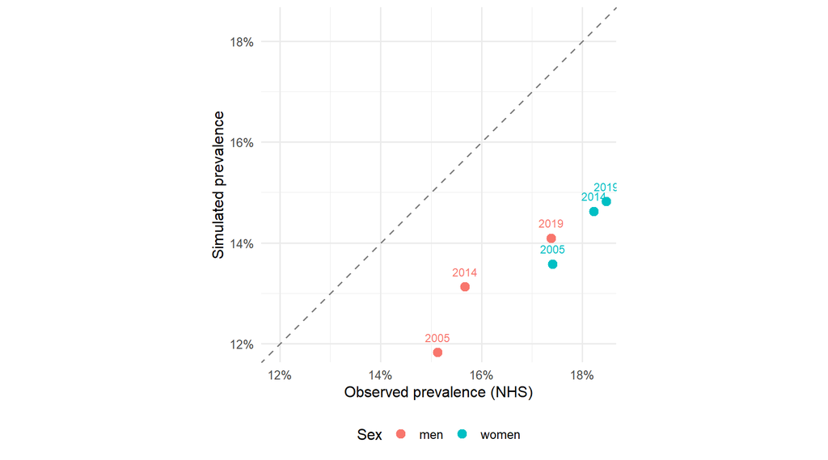

Figure 3: Calibration plot for obesity prevalence: simulated versus observed NHS prevalence. The dashed 45° line indicates exact agreement; all points below it indicate underestimation.

```r
yll_results <- ponte_calculate_yll(
  simulation_output = simulation_historical,
  ref_age = 75L,
  min_age = 20L,
  max_age = 84L
)

required_yll_outputs <- c("by_year", "overall")

missing_yll_outputs <- setdiff(
  required_yll_outputs,
  names(yll_results)
)

if (length(missing_yll_outputs) > 0L) {
  stop(
    "`ponte_calculate_yll()` is missing required output(s): ",
    paste(missing_yll_outputs, collapse = ", "),
    call. = FALSE
  )
}

write_result_csv(
  yll_results$by_year,
  "module2_yll_by_year.csv"
)

write_result_csv(
  yll_results$overall,
  "module2_yll_overall.csv"
)
```

Table 5: Simulated all-cause years of life lost by sex and education level, 1998–2040. Mortality risks are adjusted for BMI category and education level; these estimates are not obesity-attributable.

| Sex | Education | Deaths (weighted) | Total YLL (weighted) | Mean YLL per death |
| --- | --- | --- | --- | --- |
| men | high | 109980 | 1194037 | 10.86 |
| men | low | 1115992 | 6905108 | 6.19 |
| men | medium | 359160 | 4437453 | 12.36 |
| women | high | 75680 | 949303 | 12.54 |
| women | low | 779844 | 3214022 | 4.12 |
| women | medium | 188690 | 1952062 | 10.35 |

Annual YLL time-series are not displayed because estimates are based on a single stochastic simulation and show substantial year-to-year Monte Carlo variation. Results are therefore summarised over the full 1998–2040 period.

### 2.2 Total Weighted Quality-adjusted Life Years

QALYs are calculated for alive simulated individuals using age- and sex-specific EQ-5D utility norms, with BMI-related utility decrements applied to those with BMI at or above 25 kg/m².

The current implementation returns population-weighted QALY totals by year, sex, and education group. This report aggregates these to the total simulated population. It does not report QALYs per person or education-specific QALY inequalities, because the current output does not retain the denominator or individual-level utility values needed for those comparisons.

```r
qaly_results <- ponte_calculate_qalys(
  simulation_output = simulation_historical,
  min_age = 20L,
  max_age = 84L
)

if (!"by_year" %in% names(qaly_results)) {
  stop(
    "`ponte_calculate_qalys()` must return an object named `by_year`.",
    call. = FALSE
  )
}


write_result_csv(
  qaly_results$by_year,
  "module2_qalys_by_year.csv"
)

if ("overall" %in% names(qaly_results)) {
  write_result_csv(
    qaly_results$overall,
    "module2_qalys_overall.csv"
  )
}

qaly_results_total <- qaly_results$by_year |>
  group_by(year) |>
  summarise(
    total_qalys_weighted = sum(mean_qaly, na.rm = TRUE),
    .groups = "drop"
  )
```

```r
#| label: summarise-module2-qalys
#| include: false

qaly_results_total <- qaly_results$by_year |>
  group_by(year) |>
  summarise(
    total_qalys_weighted = sum(mean_qaly, na.rm = TRUE),
    .groups = "drop"
  )
```

Table 6: Annual total weighted QALYs accrued by the living simulated population, 1998–2040.

| Mean annual total QALYs (weighted) | Cumulative QALYs, 1998–2040 (weighted) |
| --- | --- |
| 6364164 | 273659056 |

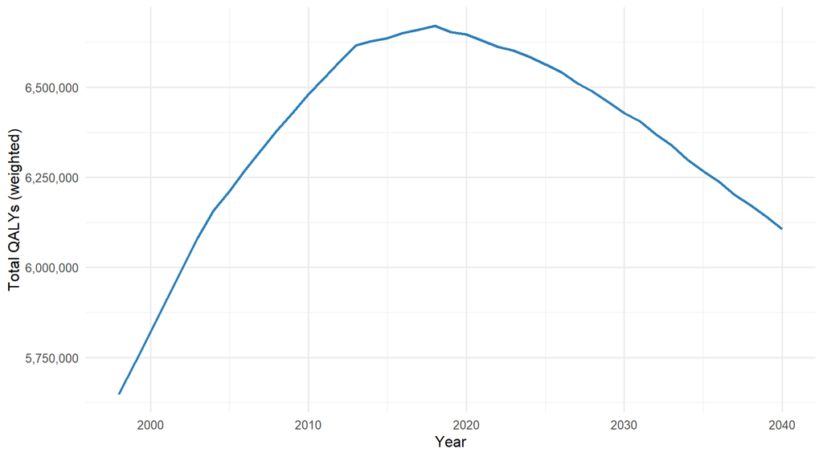

Figure 4: Annual total weighted QALYs accrued by the living simulated population, 1998–2040.

## Module 3: Obesity-Attributable Economic Costs

> **Scope note — exploratory economic scenario, not externally validated cost modelling.**  
> Costs are derived from a published 2018 Portuguese baseline and scaled using simulated obesity prevalence. No independent comparison against another cost year or data source is performed here. Results should be described as an *internally consistent economic scenario driven by the microsimulation*, not as externally validated cost estimates.

Direct costs of obesity treatment are added at 100% attribution by definition. Depression costs are retained as a descriptive published-cost category but are excluded from the obesity-attributable total because GBD 2019 does not provide a BMI-to-depression relative risk suitable for this PAF calculation.

### 3.1 GBD Relative Risks for PAF Derivation

### 3.2 Published 2018 Cost Inputs

> **Note:** `published_prevalence_2018` is retained as a published comparator and audit input. The PAF calculation below uses simulated 2018 obesity prevalence to maintain internal consistency with the microsimulation.

### 3.3 Obesity-attributable Costs in 2018

```r
exclude_groups <- c("obesity_overweight", "depression")

direct_obesity_costs <- costs_2018 |>
  filter(disease_group == "obesity_overweight")

depression_costs <- costs_2018 |>
  filter(disease_group == "depression")

costs_gbd <- costs_2018 |>
  filter(!disease_group %in% exclude_groups)

pafs_gbd <- pafs_ow_ob |>
  filter(!disease_group %in% exclude_groups)

if (nrow(direct_obesity_costs) != 1L) {
  stop(
    "Expected exactly one `obesity_overweight` cost row.",
    call. = FALSE
  )
}

if (nrow(depression_costs) != 1L) {
  stop(
    "Expected exactly one `depression` cost row.",
    call. = FALSE
  )
}

prevalence_2018_sim <- simulation_historical |>
  filter(alive, year == 2018L) |>
  group_by(sex) |>
  summarise(
    p_obesity = weighted.mean(
      bmi >= 30,
      w = survey_weight,
      na.rm = TRUE
    ),
    .groups = "drop"
  ) |>
  mutate(
    sex = recode(
      sex,
      "men" = "Males",
      "women" = "Females"
    )
  )

if (nrow(prevalence_2018_sim) != 2L) {
  stop(
    "Expected simulated obesity prevalence for men and women in 2018.",
    call. = FALSE
  )
}

if (anyNA(prevalence_2018_sim$p_obesity)) {
  stop(
    "Simulated 2018 obesity prevalence contains missing values.",
    call. = FALSE
  )
}

obesity_costs <- calculate_obesity_costs(
  rr_obesity = rr_obesity_gbd,
  outcome_mapping = cost_mapping,
  prevalence = prevalence_2018_sim,
  costs_dro = costs_gbd,
  paf_ow_ob = pafs_gbd
)

required_cost_outputs <- c("costs_by_group", "paf_by_group", "total_costs")

missing_cost_outputs <- setdiff(
  required_cost_outputs,
  names(obesity_costs)
)

if (length(missing_cost_outputs) > 0L) {
  stop(
    "`calculate_obesity_costs()` is missing output(s): ",
    paste(missing_cost_outputs, collapse = ", "),
    call. = FALSE
  )
}

write_result_csv(
  prevalence_2018_sim,
  "module3_simulated_obesity_prevalence_2018.csv"
)

write_result_csv(
  obesity_costs$costs_by_group,
  "module3_obesity_costs_by_group_2018.csv"
)

write_result_csv(
  obesity_costs$paf_by_group,
  "module3_obesity_pafs_by_group_2018.csv"
)
```

```r
#| label: create-module3-combined-total
#| include: false

required_gbd_total_columns <- c(
  "inpatient_obesity_total",
  "outpatient_obesity_total",
  "pharmacological_obesity_total",
  "total_obesity"
)

missing_gbd_total_columns <- setdiff(
  required_gbd_total_columns,
  names(obesity_costs$total_costs)
)

if (length(missing_gbd_total_columns) > 0L) {
  stop(
    "`obesity_costs$total_costs` is missing: ",
    paste(missing_gbd_total_columns, collapse = ", "),
    ". Available columns: ",
    paste(names(obesity_costs$total_costs), collapse = ", "),
    call. = FALSE
  )
}

required_published_cost_columns <- c(
  "inpatient",
  "outpatient",
  "pharmacological",
  "total"
)

missing_published_cost_columns <- setdiff(
  required_published_cost_columns,
  names(direct_obesity_costs)
)

if (length(missing_published_cost_columns) > 0L) {
  stop(
    "`direct_obesity_costs` is missing: ",
    paste(missing_published_cost_columns, collapse = ", "),
    ". Available columns: ",
    paste(names(direct_obesity_costs), collapse = ", "),
    call. = FALSE
  )
}

gbd_cost_total <- obesity_costs$total_costs |>
  summarise(
    inpatient_k_eur = sum(inpatient_obesity_total, na.rm = TRUE),
    outpatient_k_eur = sum(outpatient_obesity_total, na.rm = TRUE),
    pharmacological_k_eur = sum(
      pharmacological_obesity_total,
      na.rm = TRUE
    ),
    total_k_eur = sum(total_obesity, na.rm = TRUE)
  )

direct_obesity_total <- direct_obesity_costs |>
  summarise(
    inpatient_k_eur = sum(inpatient, na.rm = TRUE),
    outpatient_k_eur = sum(outpatient, na.rm = TRUE),
    pharmacological_k_eur = sum(pharmacological, na.rm = TRUE),
    total_k_eur = sum(total, na.rm = TRUE)
  )

cost_components <- bind_rows(
  gbd_cost_total |>
    mutate(component = "GBD-based downstream disease costs"),
  direct_obesity_total |>
    mutate(component = "Direct obesity-treatment costs")
)

combined_obesity_cost_total <- bind_rows(
  cost_components,
  cost_components |>
    summarise(
      component = "Combined obesity-attributable costs",
      inpatient_k_eur = sum(inpatient_k_eur, na.rm = TRUE),
      outpatient_k_eur = sum(outpatient_k_eur, na.rm = TRUE),
      pharmacological_k_eur = sum(pharmacological_k_eur, na.rm = TRUE),
      total_k_eur = sum(total_k_eur, na.rm = TRUE)
    )
) |>
  select(
    component,
    inpatient_k_eur,
    outpatient_k_eur,
    pharmacological_k_eur,
    total_k_eur
  )

write_result_csv(
  combined_obesity_cost_total,
  "module3_combined_obesity_cost_total_2018.csv"
)
```

Table 7: Published cost groups handled outside the GBD-based PAF calculation. Direct obesity-treatment costs are included at 100% attribution. Depression costs are shown for context but excluded from the obesity-attributable total.

| Disease group | Inpatient (k€) | Outpatient (k€) | Pharmacological (k€) | Total (k€) | Treatment | Rationale |
| --- | --- | --- | --- | --- | --- | --- |
| obesity_overweight | 5468 | 1447 | 6368 | 13283 | Included | PAF = 1.0 by definition |
| depression | 477 | 6823 | 19542 | 26843 | Excluded | No BMI-to-depression GBD relative risk |

Table 8: Combined obesity-attributable direct medical costs in 2018. The combined total includes GBD-based downstream disease costs and direct obesity-treatment costs. Depression is excluded because no GBD BMI-to-depression relative risk was used.

| Cost component | Inpatient (k€) | Outpatient (k€) | Pharmacological (k€) | Total (k€) |
| --- | --- | --- | --- | --- |
| GBD-based downstream disease costs | 68887 | 310404 | 294328 | 673620 |
| Direct obesity-treatment costs | 5468 | 1447 | 6368 | 13283 |
| Combined obesity-attributable costs | 74355 | 311851 | 300696 | 686903 |

### 3.4 Interpretation and limitations

- The GBD relative-risk transformation evaluates the risk contrast at BMI 32 kg/m² relative to BMI 22 kg/m². It is a representative obesity-versus-reference scenario, not a continuous BMI-distribution PAF calculation.
- The published direct-cost matrix includes overweight-and-obesity costs, whereas downstream disease attribution is recalculated for obesity only. Do not interpret the resulting totals as directly comparable without this qualification.
- Direct treatment costs are included at full attribution because they represent the cost of treating obesity itself.
- Depression costs are excluded from the attributable total because no BMI-to-depression GBD relative risk is used in this analysis.
- The estimates are exploratory and internally consistent with the microsimulation; they have not been externally validated against another Portuguese cost year or administrative source.

### 3.5 Cost Trajectories, 2018–2040

Obesity-attributable direct medical costs are projected from the combined 2018 baseline by scaling annual costs in proportion to simulated obesity prevalence. The analysis reports annual resource costs in constant 2018 euros and annual costs expressed as 2026 present values. Costs are converted to 2026 euros using a CPI index of 117.22 (2018 = 100); this is an explicit conservative assumption for the 2025–2026 value. Costs from 2027 onward are discounted to 2026 at 3% per year.

```r
cost_trajectory <- sim_prev_combined |>
  mutate(
    prevalence_scale = obesity_prev / prev_2018_sim,
    cost_constant_2018eur = base_total_cost_2018 * prevalence_scale,
    cost_2026eur_undiscounted = cost_constant_2018eur * (cpi_2026 / 100),
    discount_factor = if_else(
      year > 2026L,
      1 / ((1 + discount_rate) ^ (year - 2026L)),
      1
    ),
    cost_2026pv = cost_2026eur_undiscounted * discount_factor
  ) |>
  select(
    year,
    obesity_prev,
    prevalence_scale,
    discount_factor,
    cost_constant_2018eur,
    cost_2026eur_undiscounted,
    cost_2026pv
  )

write_result_csv(
  cost_trajectory,
  "module3_cost_trajectory_2018_2040.csv"
)

write_result_csv(
  sim_prev_detail,
  "module3_cost_prevalence_by_sex_education.csv"
)
```

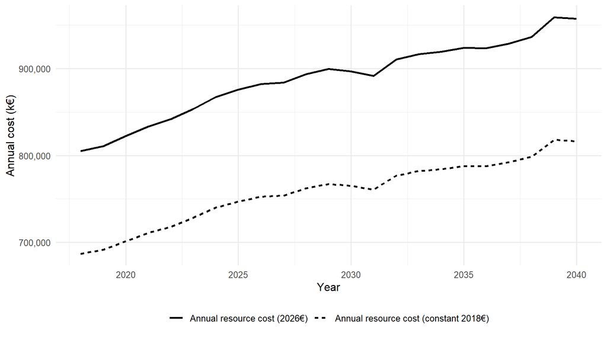

Figure 5: Projected annual obesity-attributable direct medical costs, 2018–2040. Costs are prevalence-scaled from the 2018 baseline and expressed in constant 2018 euros and 2026 euros. Both series represent annual resource costs and rise as simulated obesity prevalence increases.

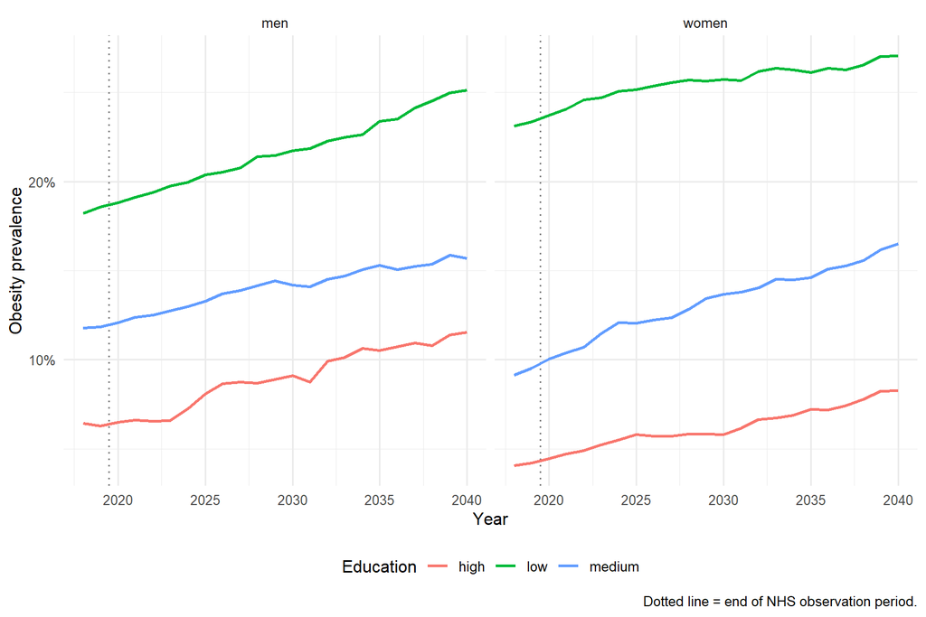

Figure 6: Simulated obesity prevalence underlying the projected cost trajectory, by sex and education level, 2018–2040.

Table 9: Projected obesity-attributable direct medical costs, 2018–2040. Resource costs are shown in constant 2018 euros and as 2026-present-value costs after conversion to 2026 euros and discounting from 2027.

| Year | Obesity prevalence | Prevalence scale | Discount factor | Cost (constant 2018€, k) | Cost (2026€, undiscounted, k) | Cost (2026 PV, k) |
| --- | --- | --- | --- | --- | --- | --- |
| 2018 | 14.4% | 1.000 | 1.000 | 686903 | 805188 | 805188 |
| 2019 | 14.5% | 1.007 | 1.000 | 691758 | 810879 | 810879 |
| 2020 | 14.7% | 1.021 | 1.000 | 701526 | 822328 | 822328 |
| 2021 | 14.9% | 1.035 | 1.000 | 710852 | 833261 | 833261 |
| 2022 | 15.0% | 1.045 | 1.000 | 718013 | 841655 | 841655 |
| 2023 | 15.2% | 1.060 | 1.000 | 728213 | 853611 | 853611 |
| 2024 | 15.5% | 1.077 | 1.000 | 739947 | 867366 | 867366 |
| 2025 | 15.6% | 1.087 | 1.000 | 746993 | 875625 | 875625 |
| 2026 | 15.7% | 1.096 | 1.000 | 752526 | 882111 | 882111 |
| 2027 | 15.8% | 1.097 | 0.971 | 753815 | 883623 | 857886 |
| 2028 | 15.9% | 1.110 | 0.943 | 762224 | 893479 | 842189 |
| 2029 | 16.0% | 1.117 | 0.915 | 767329 | 899463 | 823136 |
| 2030 | 16.0% | 1.114 | 0.888 | 765061 | 896804 | 796799 |
| 2031 | 15.9% | 1.107 | 0.863 | 760548 | 891514 | 769028 |
| 2032 | 16.2% | 1.131 | 0.837 | 776704 | 910453 | 762490 |
| 2033 | 16.4% | 1.139 | 0.813 | 782041 | 916708 | 745368 |
| 2034 | 16.4% | 1.142 | 0.789 | 784197 | 919235 | 725653 |
| 2035 | 16.5% | 1.147 | 0.766 | 787904 | 923581 | 707848 |
| 2036 | 16.5% | 1.147 | 0.744 | 787754 | 923405 | 687100 |
| 2037 | 16.6% | 1.153 | 0.722 | 792290 | 928722 | 670928 |
| 2038 | 16.7% | 1.163 | 0.701 | 798709 | 936247 | 656665 |
| 2039 | 17.1% | 1.191 | 0.681 | 817997 | 958856 | 652934 |
| 2040 | 17.1% | 1.189 | 0.661 | 816519 | 957123 | 632771 |